# Interactive Statistics Graphics with plotly

Cheng Peng

West Chester University

## plotly

There are two main ways to creating a `plotly` object: either by transforming a ggplot2 object into a plotly object via `ggplotly()` or by directly initializing a plotly object with `plot_ly()`/`plot_geo()`/`plot_mapbox()`. Plotly has a rich and complex set of features. The most common features are:

- Tooltip “hover” info
- Zoom in and out of graphs
- Users can export graphs as an image
- Integrating multiple graphs
- Template hover info
- Animations and moving graphics

One can feed a `ggplot` to `plotly` to render ggplot via `plotly` by using `ggplotly()` - a wrapper of `ggplot`. Comparing to the base R plotting function `plot()`, `plot_ly()` is more technical and poorly documented. However, the following factors may make `plotly` the best option:

- graphs presented in a digital/online format
- users interact with the graph
- more customizable than ggplot
- rendering graphics in a higher-resolution

In this note, we introduce the basic statistical graphics using the `plotly` package. `plotly` graphics automatically contain interactive elements that allow users to modify, explore, and experience the visualized data in new ways.

The coding effort is similar to that of SAS ODS graphics. To use `plot_ly()`, we need to install (if not done) and load the `plotly` package. We use the well-known iris data set in the following plots. A nice `plotly` cheat sheet can be found at https://pengdsci.github.io/STA553VIZ/w06/r_plotly_cheat_sheet.pdf

The gramma of `plot_ly()` is similar to that of `ggplot()`. By specifying `text` option, we can customize the hover text. If `text` option is not specified, the default hover text is just the `x=` and `y=` coordinates of that data point, and the variables in the `color=` option and `marks=` option. In addtion, we can group the data points by color and size just as in ggplot2. To add a layer in the graph, such as fitting a linear regression line, we use `add_trace`.

## ScatterPlot

### The Default Plot

First, we make a simple interactive scatter plot using sepal length and width. We can view the information about the variables and color coding information in the hover text. The labels of axes and legend titles and label are default.

```r
plot_ly(
    data = iris,
    x = ~Sepal.Length,  # Horizontal axis
    y = ~Sepal.Width,   # Vertical axis
    color = ~factor(Species),  # must be a numeric factor
     type = "scatter",
     mode = "markers")
```

[interactive chart not shown]

### Including Additional Information Through `hovertemplate`

We can also add additional information to the plot to enhance interactivity of the plot. For example, we can

1. modify the point size using the value of a numerical variable variable;
2. add text to the hover text using `text` option to show the class label;
3. formulate the hover text using `hovertemplate` option.

`hovertemplate`

```r
plot_ly(
    data = iris,
    x = ~Sepal.Length,         # Horizontal axis
    y = ~Sepal.Width,          # Vertical axis
    customdata = ~Petal.Width,
    color = ~factor(Species),  # must be a numeric factor
     hovertext = ~Species,          # show the species in the hover text
     hoverlabel = ~Petal.Width,
     ####
     marker = list(size = ~Petal.Length, sizeref = .05, sizemode = 'area'),
     #
     alpha  = 0.9,
     type = "scatter",
     mode = "markers",
     ## using the following hovertemplate() to add the information of the
     ## two numerical variable to the hover text.
     hovertemplate = paste('<b>Sepal Width<b>: %{y}',
                           '<br><b>Sepal Length</b>: %{x}',
                           '<br><b>Petal Length</b>: %{marker.size:,}',
                           '<br><b>Petal Width</b>: %{customdata}',
                           '<br><b>Species</b>: %{hovertext}',
                           "<extra></extra>")
     ###
)
```

[interactive chart not shown]

### Enhancing the Plot with Layout() Function

Titles and axis labels are important in any visualization, to include a meaningful titles, informative labels , and annotations to the plotly plot, we can use layout() function. The following code only gives you some design idea you can use to enhance your plotly charts. The detailed list of configurations can be found from the plotly’s reference page at https://plotly.com/r/reference/layout/

```r
plot_ly(
    data = iris,
    x = ~Sepal.Length,  # Horizontal axis
    y = ~Sepal.Width,   # Vertical axis
    color = ~factor(Species),  # must be a numeric factor
    #text = ~Species,
    text = ~paste("Petal Length: ", Petal.Length,
                   "<br>Petal Width: ", Petal.Width,
                   "<br>Species: ", Species),
     # show the species in the hover text
     ## using the following hovertemplate() to add the information of the
     ## two numerical variable to the hover text.
     ### using the following hover template to display more information
     hovertemplate = paste('<i><b>Sepal Width<b></i>: %{y}',
                           '<br><b>Sepal Length</b>:  %{x}',
                           '<br><b>%{text}</b>'),
     alpha  = 0.6,
     marker = list(size = ~Petal.Length, sizeref = .05, sizemode = 'area' ),
     type = "scatter",
     mode = "markers",
     ## graphic size
     width = 700,
     height = 500
   ) %>%
    layout(
      ### Title
      title =list(text = "Sepal Length vs Sepal Width",
                  font = list(family = "Times New Roman",  # HTML font family
                                size = 18,
                               color = "red")),
      ### legend
      legend = list(title = list(text = 'species',
                                 font = list(family = "Courier New",
                                               size = 14,
                                              color = "green")),
                    bgcolor = "ivory",
                    bordercolor = "navy",
                    groupclick = "togglegroup",  # one of  "toggleitem" AND "togglegroup".
                    orientation = "v"  # Sets the orientation of the legend.
                    ),
      ## margin of the plot
      margin = list(
              b = 100,
              l = 100,
              t = 100,
              r = 50
      ),
      ## Background
      plot_bgcolor ='#f7f7f7',
      ## Axes labels
             xaxis = list(
                    title=list(text = 'Sepal Length',
                               font = list(family = 'Arial')),
                    zerolinecolor = 'red',
                    zerolinewidth = 2,
                    gridcolor = 'white'),
            yaxis = list(
                    title=list(text = 'Sepal Width',
                               font = list(family = 'Arial')),
                    zerolinecolor = 'purple',
                    zerolinewidth = 2,
                    gridcolor = 'white'),
       ## annotations
       annotations = list(
                     x = 0.7,   # between 0 and 1. 0 = left, 1 = right
                     y = 1.5,   # between 0 and 1, 0 = bottom, 1 = top
                  font = list(size = 12,
                              color = "darkred"),
                  text = "The point size is proportional to the sepal length",
                  xref = "paper",  # "container" spans the entire `width` of the
                                   #  lot. "paper" refers to the width of the
                                   #  plotting area only. yref = "paper",
                                   #  same as xref.
               xanchor = "center", #  horizontal alignment with respect to its x position
               yanchor = "bottom", #  similar to xanchor
             showarrow = FALSE)
    )
```

[interactive chart not shown]

We also write a theme just like we did in the regular ggplot. The following is an example.

```r
myPlotlyLayout <- function(anyObjName){  # anyString is required initial argument.
                                        # it can be any string a,b,c, .........
  layout(anyObjName,
      ### Title
      title =list(text = "Sepal Length vs Sepal Width",
                          font = list(family = "Times New Roman",  # HTML font family
                                        size = 18,
                                       color = "red")),
      ### legend
      legend = list(title = list(text = 'species',
                                 font = list(family = "Courier New",
                                               size = 14,
                                              color = "green")),
                    bgcolor = "ivory",
                    bordercolor = "navy",
                    groupclick = "togglegroup",  # one of  "toggleitem" AND "togglegroup".
                    orientation = "v"  # Sets the orientation of the legend.

                    ),
      ## margin of the plot
      margin = list(
              b = 120,
              l = 50,
              t = 120,
              r = 50
      ),
      ## Background
      plot_bgcolor ='#f7f7f7',
      ## Axes labels
             xaxis = list(
                    title=list(text = 'Sepal Length',
                               font = list(family = 'Arial')),
                    zerolinecolor = 'red',
                    zerolinewidth = 2,
                    gridcolor = 'white'),
            yaxis = list(
                    title=list(text = 'Sepal Width',
                               font = list(family = 'Arial')),
                    zerolinecolor = 'purple',
                    zerolinewidth = 2,
                    gridcolor = 'white'),
       ## annotations
       annotations = list(
                     x = 0.7,   # between 0 and 1. 0 = left, 1 = right
                     y = 0.9,   # between 0 and 1, 0 = bottom, 1 = top
                  font = list(size = 12,
                              color = "darkred"),
                  text = "The point size is proportional to the sepal length",
                  xref = "paper",  # "container" spans the entire `width` of the plot.
                                   # "paper" refers to the width of the plotting area only.
                  yref = "paper",  #  same as xref
               xanchor = "center", #  horizontal alignment with respect to its x position
               yanchor = "bottom", #  similar to xanchor
             showarrow = FALSE
           )
  )
       }
```

```r
plot_ly(
    data = iris,
    x = ~Sepal.Length,  # Horizontal axis
    y = ~Sepal.Width,   # Vertical axis
    color = ~factor(Species),  # must be a numeric factor
     text = ~Species,     # show the species in the hover text
     ## using the following hovertemplate() to add the information of the
     ## two numerical variable to the hover text.
     hovertemplate = paste('<i><b>Sepal Width<b></i>: %{y}',
                           '<br><b>Sepal Length</b>:  %{x}',
                           '<br><b>%{text}</b>'),
     alpha  = 0.9,
     marker = list(size = ~Petal.Length, sizeref = .05, sizemode = 'area' ),
     type = "scatter",
     mode = "markers",
     ## graphic size
     width = 700,
    height = 500) %>% myPlotlyLayout()
```

[interactive chart not shown]

### External Images for plotly Charts

As we did in the base R and ggplot, we illustrate how to add images to plotly charts: inserting an image and setting an image background.

**Inserting Images to `plotly` Charts**

The following example shows how to use layout function to insert an external image to a plotly scatter plot. Comparing the steps of inserting an external image to the base R and ggplot, it is relatively straightforward and flexible to perform the same task in plotly. See the comments in the code to place the image in an appropriate location.

```r
plot_ly(
    data = iris,
    x = ~Sepal.Length,         # Horizontal axis
    y = ~Sepal.Width,          # Vertical axis
    customdata = ~Petal.Width,
    color = ~factor(Species),  # must be a numeric factor
     hovertext = ~Species,          # show the species in the hover text
     hoverlabel = ~Petal.Width,
     ####
     marker = list(size = ~Petal.Length, sizeref = .05, sizemode = 'area'),
     #
     alpha  = 0.9,
     type = "scatter",
     mode = "markers",
     ## using the following hovertemplate() to add the information of the
     ## two numerical variable to the hover text.
     hovertemplate = paste('<b>Sepal Width<b>: %{y}',
                           '<br><b>Sepal Length</b>: %{x}',
                           '<br><b>Petal Length</b>: %{marker.size:,}',
                           '<br><b>Petal Width</b>: %{customdata}',
                           '<br><b>Species</b>: %{hovertext}',
                           "<extra></extra>") ) %>%
    layout(
      images = list(
      list(
        source = "https://pengdsci.github.io/STA553VIZ/w06/img/iris.jpeg",
        xref="paper",  # without assuming having a coordinate system, we
        yref="paper",  # can use paper size to set up a relative location
                       # to place an image.
                       # We can also use  xref="x domain", yref="y domain",
                       # to set up a coordinate system to place an image.
        x = 0,     # value between 0 and 1 - representing percentage from left
                   # hand side of x (0) and the right hand side of x (1).
        y = 1,     # x = 0, y = 1 ==> "topleft"
        sizex = .2,   #  image size - horizontal
        sizey = .2,   #  vertical size
        xanchor="left",  # image location -
        yanchor="top" ,
        opacity = 0.6    # adjusting image opacity
      )
    )
  )
```

[interactive chart not shown]

**Setting Image Background for plotly Charts**

```r
pal <- c("#332288", "#117733", "#882255")
pal <- setNames(pal, c("virginica", "setosa", "versicolor"))

plot_ly(
    data = iris,
    x = ~Sepal.Length,         # Horizontal axis
    y = ~Sepal.Width,          # Vertical axis
    customdata = ~Petal.Width,
    color = ~factor(Species),   # must be a numeric factor
    colors = pal,               # custom color palette
     hovertext = ~Species,      # show the species in the hover text
     hoverlabel = ~Petal.Width,
     ####
     marker = list(size = ~Petal.Length, sizeref = .05, sizemode = 'area'),
     #
     alpha  = 0.9,
     type = "scatter",
     mode = "markers",
     ## using the following hovertemplate() to add the information of the
     ## two numerical variable to the hover text.
     hovertemplate = paste('<b>Sepal Width<b>: %{y}',
                           '<br><b>Sepal Length</b>: %{x}',
                           '<br><b>Petal Length</b>: %{marker.size:,}',
                           '<br><b>Petal Width</b>: %{customdata}',
                           '<br><b>Species</b>: %{hovertext}',
                           "<extra></extra>") ) %>%
    layout(
    images = list(
      list(
        # Add images
        source =  "https://pengdsci.github.io/STA553VIZ/w06/img/irisbg.jpg",
        xref = "x",
        yref = "y",
        x = 4,
        y = 4.5,
        sizex = 7,
        sizey = 3,
        sizing = "stretch",
        opacity = 0.5,
        layer = "below"
      )
    )
  )
```

[interactive chart not shown]

### Animated Graphs with plotly

When a data set involves time variable, we use also use movement to represent the time variable. `plot_ly()` can create animated graphs. The following is an example using the built-in `gapminder data set` in the library `gapminder` that displaying the relationship between life-expectancy and GDP per capita of countries over the time (by every 5 years).

```r
pal.IBM <- c("#332288", "#117733", "#88CCEE","#DDCC77", "#882255")
pal.IBM <- setNames(pal.IBM, c("Asia", "Europe", "Africa", "Americas", "Oceania"))

df <- gapminder
fig <- df %>%
  plot_ly(
    x = ~gdpPercap,
    y = ~lifeExp,
    marker = list(size = ~log(pop), sizeref = 1.5, sizemode = 'radius'),
    color = ~continent,
    colors = pal.IBM,   # custom colors
    frame = ~year,      # the time variable to
    text = ~country,    # to display in the hover
    hoverinfo = "text",
    type = 'scatter',
    mode = 'markers'
  )
fig <- fig %>% layout(
    xaxis = list(
      type = "log"
    )
  )

fig
```

[interactive chart not shown]

### Redering A GGPLOT with `ggplotly`

We can also render a ggplot in using ggplotly to bring interactivity to the plot. The next is a customary theme to layout ggplots.

```r
myplot.theme_new <- function() {
  theme(
    #ggplot margins
     plot.margin = margin(t = 50,  # Top margin
                          r = 30,  # Right margin
                          b = 30,  # Bottom margin
                          l = 30), # Left margin
    ## ggplot titles
    plot.title = element_text(face = "bold",
                              size = 12,
                              family = "sans",
                              color = "navy",
                              hjust = 0.5,
                              margin=margin(0,0,30,0)), # left(0),right(1)
    # add border 1)
    panel.border = element_rect(colour = NA,
                                fill = NA,
                                linetype = 2),
    # color background 2)
    panel.background = element_rect(fill = "#f6f6f6"),
    # modify grid 3)
    panel.grid.major.x = element_line(colour = 'white',
                                      linetype = 3,
                                      size = 0.5),
    panel.grid.minor.x = element_blank(),
    panel.grid.major.y =  element_line(colour = 'white',
                                       linetype = 3,
                                       size = 0.5),
    panel.grid.minor.y = element_blank(),
    # modify text, axis and colour 4) and 5)
    axis.text = element_text(colour = "navy",
                             #face = "italic",
                             size = 7,
                             #family = "Times New Roman"
                             ),
    axis.title = element_text(colour = "navy",
                              size = 7,
                              #family = "Times New Roman"
                              ),
    axis.ticks = element_line(colour = "navy"),
    # legend at the bottom 6)
    legend.position = "bottom",
    legend.key.size = unit(0.6, 'cm'), #change legend key size
    legend.key.height = unit(0.6, 'cm'), #change legend key height
    legend.key.width = unit(0.6, 'cm'), #change legend key width
    #legend.title = element_text(size=8), #change legend title font size
    legend.title=element_blank(),  # remove all legend titles
    legend.key = element_rect(fill = "white"),
    #####
    legend.text = element_text(size=8)) #change legend text font size
}
```

The following plot uses the above theme and passes the correlation coefficient to the annotated text.

```r
p <- ggplot(iris, aes(x = Sepal.Length, y = Sepal.Width,
                              color = factor(Species))) +
             aes(label = Species, label1 = Petal.Length, label2 =  Petal.Width) +
             ## The labels in the above aes() will be part of the hover text.
             geom_point(size = iris$Petal.Length, alpha = 0.7) +
             stat_smooth(method = lm, se=FALSE, size = 0.5) +   # add a linear regression line
             scale_color_manual(values=c("dodgerblue4", "darkolivegreen4", "darkred")) +
             labs(
                 x = "Sepal Length",
                 y = "Sepal Width",
                 title = "Association between Sepal Length and Width") +
             myplot.theme_new() +
              annotate(geom="text" ,
                       x=6.8,
                       y=2,
                       label=paste("The Pearson correlation coefficient r = ",
                                   round(cor(iris$Sepal.Length, iris$Sepal.Width),3)),
                          size = 2,
                          color = "navy") +
               coord_fixed(1)    ## This changes the aspect ratio of the graph
ggplotly(p)
```

[interactive chart not shown]

```r
p <- ggplot(iris, aes(x = Sepal.Length, y = Sepal.Width,
                      color = factor(Species)), linetype = Species) +
             # to add more information about the variables in the data set
             # use labels to denote the variable names inside the function aes()
             aes(label=Species, label2=Petal.Length, label3=Petal.Width) +
             geom_point(size = 2, alpha = 0.7) +
             stat_smooth(method = lm, se=FALSE, size = 0.3) +
             scale_color_manual(values=c("dodgerblue4", "darkolivegreen4", "darkred")) +
             labs(
                 x = "Sepal Length",
                 y = "Sepal Width",
                 title = "Association between Sepal Length and Width") +
             myplot.theme_new() +
              annotate(geom="text" ,
                       x=6.8,
                       y=2,
                       label=paste("The Pearson correlation coefficient r = ",
                                   round(cor(iris$Sepal.Length, iris$Sepal.Width),3)),
                          size = 2,
                          color = "navy") +
               coord_fixed(1)    ## This changes the aspect ratio of the graph
ggplotly(p)
```

[interactive chart not shown]

## Bar & Pie Chart

### Barplot

We will create a summarized data set to make bar plots. We define a data set to store the mean of sepal length and sepal width by species using the `dyplr` and `tidyr` approaches.

```r
barplotdata <- iris %>%
  group_by(Species) %>%
  summarize(sepal.l.avg = mean(Sepal.Length),
            sepal.w.avg = mean(Sepal.Width),
            petal.l.avg = mean(Petal.Length),
            petal.w.avg = mean(Petal.Width))
kable(head(barplotdata))
```

| Species | sepal.l.avg | sepal.w.avg | petal.l.avg | petal.w.avg |
| --- | --- | --- | --- | --- |
| setosa | 5.006 | 3.428 | 1.462 | 0.246 |
| versicolor | 5.936 | 2.770 | 4.260 | 1.326 |
| virginica | 6.588 | 2.974 | 5.552 | 2.026 |

Next, we draw a group bar chart.

```r
plot_ly(
  data = barplotdata,
   x = ~Species,
   y = ~sepal.l.avg,
   type = "bar",
   name = "sepal.len.avg" ) %>%
    add_trace(y=~sepal.w.avg, name = "sepal.wid.avg") %>%
    add_trace(y=~petal.l.avg, name = "petal.len.avg") %>%
    add_trace(y=~petal.w.avg, name = "petal.wid.avg") %>%
    layout( yaxis = list(title ="Mean"),
            title = "Frequency distribution of Iris attributes")
```

[interactive chart not shown]

### Pie Chart

We first define a subset from the iris data by filtering out observation with a sepal length less than 5. The pie chart will be created to see the distribution of species in the subset of the iris data. Keep in mind that the pie chart is constructed based on a frequency table.

```r
# define a working data set
subiris <- iris[iris$Sepal.Length > 5,5]
## create a frequency table in the form of data frame.
piedata = data.frame(cate =as.vector(unique(subiris)),
                     freq = as.vector(table(subiris)))
# define a color vector
colors <- c('rgb(211,94,96)', 'rgb(128,133,133)', 'rgb(144,103,167)')
# make a pie chart
plot_ly(piedata,
        labels = ~cate,
        values = ~freq,
        type = 'pie',
        textposition = 'inside',
        textinfo = 'label + percent',
        insidetextfont = list(color = '#FFFFFF'),
        #hoverinfo = 'text',
        marker = list(colors = colors,
                      line = list(color = '#FFFFFF', width = 1)),
                      #The 'pull' attribute can also be used to create space between the sectors
        showlegend = TRUE) %>%
         layout(title = 'Distribution of Species',
                xaxis = list(showgrid = FALSE, zeroline = FALSE,
                             showticklabels = FALSE),
                yaxis = list(showgrid = FALSE, zeroline = FALSE,
                             showticklabels = FALSE))
```

[interactive chart not shown]

## Histogram & Desnity

Histograms and density curves are used to display the distribution of numerical random variables. When comparing the distributions of different random variables, we can overlay the histograms or density curves.

### Comparing Distributions Using Histograms

We can overlay histograms to compare the distributions of multiple random variables.

```r
plot_ly(
  data = iris,
   x = ~ Sepal.Length,
   type = "histogram",
   nbinsx = 10,
   name = "sepal.length",
   alpha = .5,
   marker = list(line = list(color = "darkgray",  width = 2)) ) %>%
   ## adding additional histograms and stack them
    add_histogram(x = ~Sepal.Width,
                name = "sepal.width", nbinsx = 10, alpha = 0.5,
                marker = list(line = list(color = "darkgray",  width = 2))) %>%
    add_histogram(x = ~Petal.Length,
                name = "petal.length",nbinsx = 10, alpha = 0.5,
                marker = list(line = list(color = "darkgray",  width = 2))) %>%
    add_histogram(x = ~Petal.Width,
                name = "petal.width",nbinsx = 10, alpha = 0.5,
                marker = list(line = list(color = "darkgray",  width = 2))) %>%
  layout(barmode = "overlay",
         title = "Histogram of Iris Attribute",
         xaxis = list(title = "Iris Attributes",
                      zeroline = TRUE),
         yaxis = list(title = "Count",
                      zeroline =TRUE))
```

[interactive chart not shown]

The issue is that the above overlaying histograms cannot easy to distinguish when comparing more than two distributions in general. The ridgeline histogram can help in general. The following is an example of ridgeline histograms.

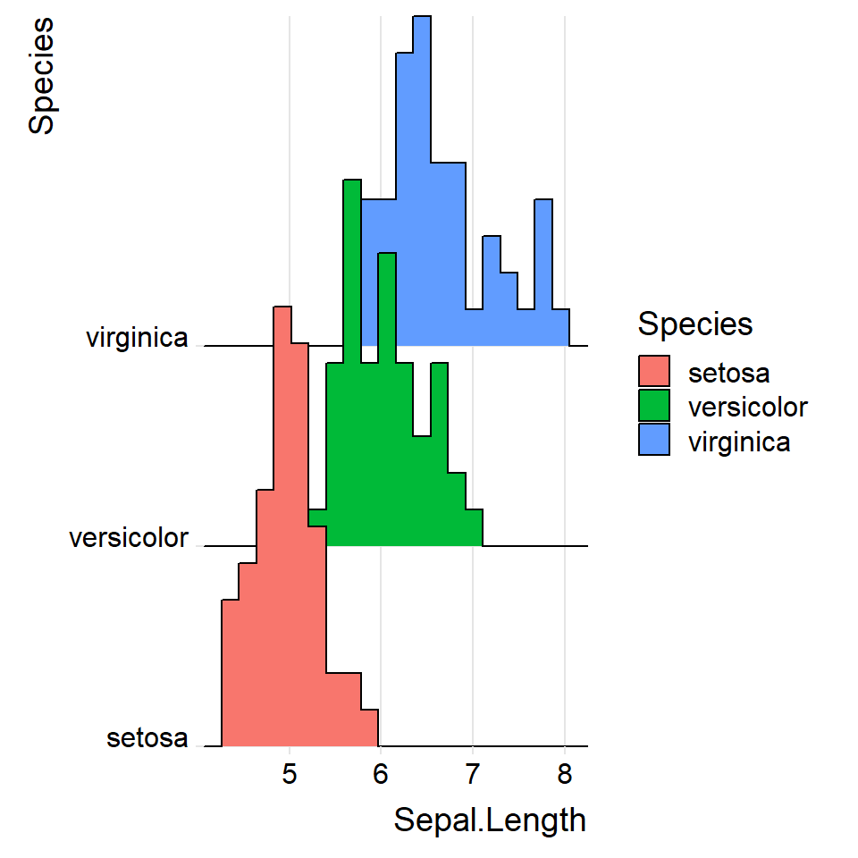

```r
ggplot(iris, aes(x = Sepal.Length, y = Species, group = Species, fill = Species)) +
  geom_density_ridges(stat = "binline", bins = 20, scale = 2.2) +
  scale_y_discrete(expand = c(0, 0)) +
  scale_x_continuous(expand = c(0, 0)) +
  coord_cartesian(clip = "off") +
  theme_ridges()
```

### Density Curve

It is relatively easy to use density curves to compare multiple distributions. Assume that we want to compare the distribution of the sepal length of the tree iris flowers. One way to do this comparison is to plot the three estimated density curves.

```r
# define three densities
sepal.len.setosa <- iris[which(iris$Species == "setosa"),]
setosa <- density(sepal.len.setosa$Sepal.Length)
sepal.len.versicolor <- iris[which(iris$Species == "versicolor"),]
versicolor <- density(sepal.len.versicolor$Sepal.Length)
sepal.len.virginica <- iris[which(iris$Species == "virginica"),]
virginica <- density(sepal.len.virginica$Sepal.Length)
# plot density curves
fig <- plot_ly(x = ~virginica$x,
               y = ~virginica$y,
               type = 'scatter', #A character string specifying the trace type
               mode = 'lines',
               name = 'virginica',
               fill = 'tozeroy')  %>%
           # adding more density curves
       add_trace(x = ~versicolor$x,
                 y = ~versicolor$y,
                 name = 'versicolor',
                 fill = 'tozeroy')  %>%
       add_trace(x = ~setosa$x,
                 y = ~setosa$y,
                 name = 'setosa',
                 fill = 'tozeroy')  %>%
       layout(xaxis = list(title = 'Sepal Length'),
              yaxis = list(title = 'Density'))
fig
```

[interactive chart not shown]

The above overlaying density plots are (with certain level of transparency) is relatively easy to visualize.

```r
ridgeDensity <- ggplot(iris, aes(x = Sepal.Length, y = Species, fill = Species)) +
  geom_density_ridges()
ggplotly(ridgeDensity)
```

[interactive chart not shown]

## Boxplot

Drawing a boxplot is straightforward in `plotly`.

```r
plot_ly(
  data = iris,
  y = ~ Sepal.Length,
  x = ~Species,
  type = "box",
  color = ~Species,
  boxpoints = "all",
  boxmean = TRUE,
  showlegend = FALSE ) %>%
   layout(title = "Histogram of Iris Attribute",
         xaxis = list(title = "Species",
                      zeroline = TRUE),
         yaxis = list(title = "Sepal Length",
                      zeroline =TRUE))
```

[interactive chart not shown]

## Serial Plot

```r
stock <- read.csv('https://raw.githubusercontent.com/pengdsci/sta553.html/main/data/finance-charts-apple.csv')
fig <- plot_ly(stock, type = 'scatter', mode = 'lines')    %>%
       add_trace(x = ~Date, y = ~AAPL.High)    %>%
       layout(showlegend = F,
              title='Time Series with Rangeslider',
              xaxis = list(rangeslider = list(visible = T)))  %>%
       layout(xaxis = list(zerolinecolor = '#ffff',
                      zerolinewidth = 2,
                      gridcolor = 'ffff'),
              yaxis = list(zerolinecolor = '#ffff',
                      zerolinewidth = 2,
                      gridcolor = 'ffff'),
              plot_bgcolor='#e5ecf6', width = 900)
fig
```

[interactive chart not shown]

## Plotly Maps

Several map libraries are available in R. In this example, we use the `plot_geo()` function from `plotly` to plot on a map.

```r
## preparing data
poc <- read_csv("https://raw.githubusercontent.com/pengdsci/sta553.html/main/data/POC.csv")[,c(7,8,9, 17)]
poc.site <- poc[poc$POC == 1,]
# geo styling
geostyle <- list(scope = 'usa',
                 projection = list(type = 'albers usa'),
                 showland = TRUE,
                 landcolor = toRGB("lightblue"),
                 subunitcolor = toRGB("purple"),
                 countrycolor = toRGB("navy"),
                 countrywidth = 0.75,
                 subunitwidth = 0.5
               )
## plotting map
fig <- plot_geo(poc.site, lat = ~ycoord, lon = ~xcoord) %>%
       add_markers(text = ~ SITE_DESCRIPTION,
                   color = "red",
                   symbol = "circle",
                   size = I(10),
                   hoverinfo = "text" )   %>%
        layout( title = 'POC Risk Sites', geo = geostyle)
fig
```

[interactive chart not shown]

## Conclusion

**Data integration**. Collect raw data and turn it into clean, analytics-ready information by performing data replication, ingestion and transformation. Then store it in a data lake or data warehouse.

**Goal definition**. Define the business objective you’re trying to achieve and the data insights you seek. For example, are you trying to optimize a production process or track the ROI of your marketing efforts.

**Visualization design**. Design begins with selecting KPIs and types of graphs, charts, and maps that best tell your story. Keeping your visualizations clean and simple will help users understand and work with the data.

**Collaboration and sharing**. Allow all approved users to explore the data freely to uncover their own insights. Your software should allow users to embed your visualizations in other applications and to engage with them on their mobile devices.